# Eras Sentiment Analysis

Maureen Ritchey

2025-04-25

## Introduction

The Eras tour has inspired endless discussion of the differences among Taylor Swift’s eras and the themes, words, and phrases that cut across them. T-Swift herself has organized some of these themes into playlists organized according to the five stages of grief. But what if we let the words do the talking?

The goal of this project is to use natural language processing tools to analyze Taylor Swift’s body of lyrics, from her debut album to *The Tortured Poets Department*. We’ll start with the Kaggle Taylor Swift lyric [database](https://www.kaggle.com/datasets/thespacefreak/taylor-swift-song-lyrics-all-albums) and adapt some ideas from [*Analyze Taylor Swift Lyrics with Python*](https://www.codecademy.com/courses/case-study-analyze-taylor-swift-lyrics/projects/analyze-taylor-swift-lyrics) and [*Tidy Text Mining with R*](https://www.tidytextmining.com/tidytext). We’ll use [tidyverse](https://www.tidyverse.org/) tools to clean up the data.

## Preliminary processing

### Load packages

```r
library(tidyverse)
library(tidytext)
```

### Load and inspect data

```r
filenames <- list.files(path="lyrics",full.names=TRUE)
df <- do.call(rbind,lapply(filenames,read.csv))

head(df)
```

|  | album_name | track_title | track_n | lyric | line |
| --- | --- | --- | --- | --- | --- |
| 1 | Taylor Swift | Tim McGraw | 1 | He said the way my blue eyes shined | 1 |
| 2 | Taylor Swift | Tim McGraw | 1 | Put those Georgia stars to shame that night | 2 |
| 3 | Taylor Swift | Tim McGraw | 1 | I said, "That's a lie" | 3 |
| 4 | Taylor Swift | Tim McGraw | 1 | Just a boy in a Chevy truck | 4 |
| 5 | Taylor Swift | Tim McGraw | 1 | That had a tendency of gettin' stuck | 5 |
| 6 | Taylor Swift | Tim McGraw | 1 | On back roads at night | 6 |

```r
# clean up titles by removing everything in parentheses
df$album_name <- str_replace(df$album_name, " \\s*\\([^\\)]+\\)", "")
df$track_title <- str_replace(df$track_title, " \\s*\\([^\\)]+\\)", "")

# convert strings to factors & put albums in order
df$album_name <- factor(df$album_name,
                        levels=c('Taylor Swift',"Fearless","Speak Now","Red",
                                 "1989","reputation","Lover","folklore","evermore",
                                 "Midnights","TTPD"))
df$track_title <- factor(df$track_title)

# number of lyrics per album
df %>%
  group_by(album_name) %>%
  count()
```

| album_name | n |
| --- | --- |
| Taylor Swift | 609 |
| Fearless | 1170 |
| Speak Now | 945 |
| Red | 1072 |
| 1989 | 1006 |
| reputation | 988 |
| Lover | 934 |
| folklore | 722 |
| evermore | 912 |
| Midnights | 811 |

[output cut: 1 more lines]

### Process lyrics

#### Clean up lyric text

```r
# lowercase everything
df$lyric.original <- df$lyric
df$lyric <- tolower(df$lyric)

# remove stop words
stopwords <- c('the', 'a', 'this', 'that', 'to', 'is', 'am', 'was', 'were', 'be', 'being', 'been', 'and', 'of', 'it', 'in', 'but', 'on', 'or')
pattern <- paste(stopwords, collapse = "\\b|\\b")
pattern <- paste0("\\b", pattern, "\\b")
df$lyric <- gsub(pattern, "", df$lyric, ignore.case = TRUE)

# remove extra whitespace
df$lyric <- str_replace_all(df$lyric, "\\s+", " ") # within lyric
df$lyric <- trimws(df$lyric) # before or after lyric
```

#### Tokenize words

```r
# unpack lyric into its component words and save to new df
df %>%
  unnest_tokens(word,lyric) -> df.tokens

# use an alternative approach to removing stopwords - this is a larger set
data(stop_words)
df.tokens <- df.tokens %>%
  anti_join(stop_words)
```

#### Count words

```r
# count most common words
token_count <- df.tokens %>%
  count(word,sort=TRUE)
head(token_count)
```

|  | word | n |
| --- | --- | --- |
| 1 | love | 340 |
| 2 | time | 321 |
| 3 | ooh | 242 |
| 4 | baby | 202 |
| 5 | gonna | 198 |
| 6 | wanna | 175 |

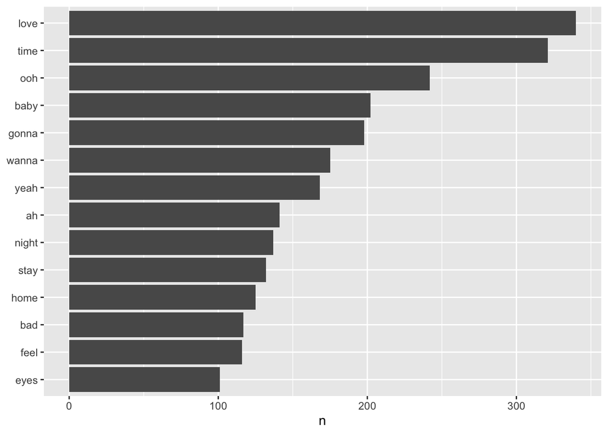

```r
# plot most common words
df.tokens %>%
  count(word, sort = TRUE) %>%
  filter(n > 100) %>%
  mutate(word = reorder(word, n)) %>%
  ggplot(aes(n, word)) +
  geom_col() +
  labs(y = NULL)
```

The most common word is “love”- no surprise there! If we hadn’t filtered out stop words, it would have been “you” shortly followed by “I”.

## Sentiment analysis of the eras

### Get valence ratings by word

```r
# get the AFINN database, which has valence scores from -5 to 5
afinn <- get_sentiments('afinn')

# combine with the tokenized lyric data
df.tokens.afinn <- df.tokens %>%
  inner_join(afinn)
# most negative words
df.tokens.afinn %>%
  select(word, value) %>%
  unique() %>%
  arrange(value) %>%
  head()
```

|  | word | value |
| --- | --- | --- |
| 1 | bitches | -5 |
| 2 | bitch | -5 |
| 3 | damn | -4 |
| 4 | hell | -4 |
| 5 | torture | -4 |
| 6 | shit | -4 |

```r
# most positive words
df.tokens.afinn %>%
  select(word, value) %>%
  unique() %>%
  arrange(-value) %>%
  head()
```

|  | word | value |
| --- | --- | --- |
| 1 | funny | 4 |
| 2 | miracle | 4 |
| 3 | wonderful | 4 |
| 4 | win | 4 |
| 5 | wins | 4 |
| 6 | masterpiece | 4 |

```r
# find lyrics with the word "win" in them
df.tokens.afinn %>%
  filter(word=="win")
```

| album_name | track_title | track_n | line | lyric.original | word | value |
| --- | --- | --- | --- | --- | --- | --- |
| Fearless | Change | 13 | 11 | For us to finally win | win | 4 |
| Fearless | Change | 13 | 24 | For us to finally win | win | 4 |
| reputation | Getaway Car | 9 | 52 | 'Cause us traitors never win | win | 4 |
| Lover | Miss Americana & The Heartbreak Prince | 7 | 16 | You play stupid games, you win stupid prizes | win | 4 |
| Lover | Miss Americana & The Heartbreak Prince | 7 | 36 | You play stupid games, you win stupid prizes | win | 4 |
| Lover | Miss Americana & The Heartbreak Prince | 7 | 42 | 'Cause nobody's gonna (Win), I think you should come home | win | 4 |
| Lover | Miss Americana & The Heartbreak Prince | 7 | 44 | 'Cause nobody's gonna (Win), I think you should come home | win | 4 |
| Lover | Miss Americana & The Heartbreak Prince | 7 | 46 | 'Cause nobody's gonna (Win), just thought you should know | win | 4 |
| Lover | Miss Americana & The Heartbreak Prince | 7 | 48 | That someday we're gonna (Win) | win | 4 |
| Lover | Miss Americana & The Heartbreak Prince | 7 | 57 | 'Cause nobody's gonna (Win), I think you should come home | win | 4 |

[output cut: 2 more lines]

A quick visual inspection reveals a major drawback of this kind of sentiment analysis: it picks up on individual words that are positive or negative but it loses the context. For instance, the lyric *You play stupid games, you win stupid prizes* gets a positive valence boost from “win” and “prizes” but the overall meaning of the metaphor is negative.

Another noticeable pattern is that swear words drag down the valence rating regardless of the way that they’re used. We’ll remove them for this analysis.

### Summarize by era

```r
# aggregate first by lyric (sentiment is often conveyed in short phrases or sentences rather than long passages) and then by track
# including overall sentiment as well as sentiment split by positive & negative weights
df.tokens.afinn %>%
  filter(word != "damn" & word != "shit" & word != "fuck" & word != "bitch" &
         word != "fucking" & word != "hell") %>%
  group_by(album_name,track_title,track_n,line) %>%
  summarize(lineval = mean(value),
            linepos = ifelse(mean(value)>0,mean(value),NA),
            lineneg = ifelse(mean(value)<0,mean(value),NA)) %>%
  group_by(album_name,track_title,track_n) %>%
  summarize(sentiment = mean(lineval),
            sentpos = mean(linepos,na.rm=TRUE),
            sentneg = mean(lineneg,na.rm=TRUE)) -> df.sentiment

# clean up positive & negative sentiment
df.sentiment %>%
  mutate(sentpos = ifelse(is.na(sentpos),0,abs(sentpos)),
         sentneg = ifelse(is.na(sentneg),0,abs(sentneg))) -> df.sentiment
```

### Plot the average sentiment of each track

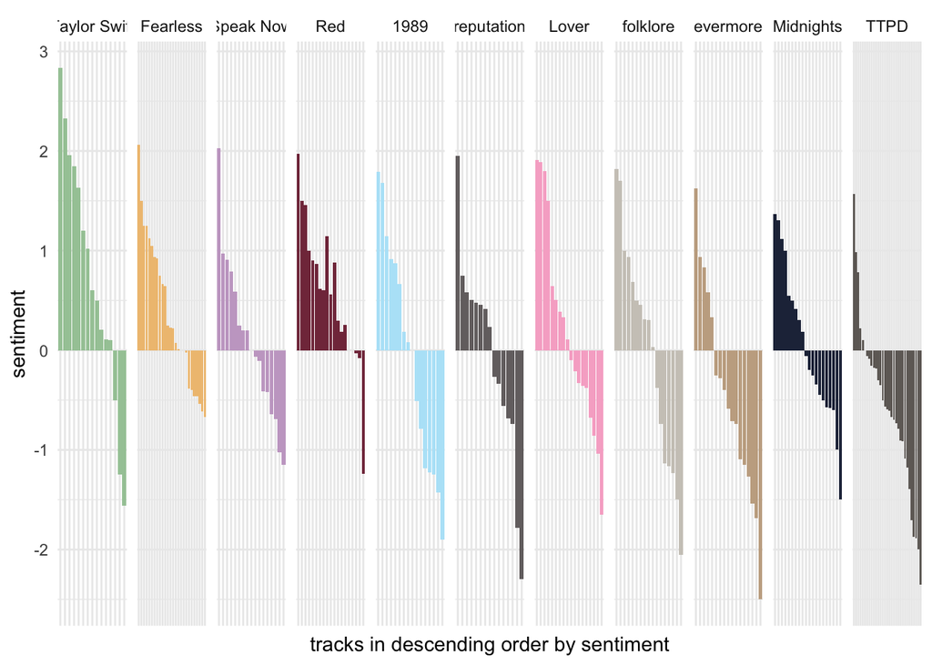

```r
# colors for the eras
era.colors <- c("#a5c9a5","#efc180","#C7a8cb","#823549","#b5e5f8","#746f70",
                "#f7b0cc","#cdc9c1","#c5ac90","#242e47","#6f6a66")

# plot the results
p <- ggplot(df.sentiment, aes(x = reorder(track_title, -sentiment),
                         y = sentiment, fill = album_name)) +
  geom_col(show.legend = FALSE) +
  scale_fill_manual(values=era.colors) +
  facet_grid(.~album_name, scales = "free_x") +
  xlab('tracks in descending order by sentiment') +
  theme_minimal() +
  theme(axis.text.x = element_blank())  # Remove x-axis tick labels

print(p)
```

What trends do you see in the data?

### Plot each track according to its positive vs negative sentiment value

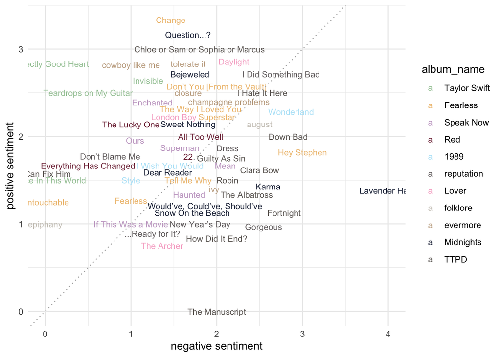

```r
# randomize row order because of check_overlap (see below)
set.seed(1234)
df.sentiment$random_order <- sample(row_number(df.sentiment))
df.sentiment %>%
  arrange(random_order) %>%
  ggplot(aes(x = sentneg, y = sentpos, color = album_name)) +
  # check_overlap shows only non-overlapping labels, entered in order of rows
  geom_text(aes(label = sprintf("%s", track_title)),size=3,check_overlap=TRUE) +
  geom_abline(slope=1,intercept=0,color="grey70",linetype="dotted") +
  scale_color_manual(values=era.colors) +
  xlab('negative sentiment') +
  ylab('positive sentiment') +
  theme_minimal()
```

Songs along the diagonal are more balanced, whereas songs off the diagonal tend to have more positive (or negative) sentiment. Songs toward the bottom left tend to have less sentiment conveyed by their lyrics.

What else would you want to visualize?